# W4_Limma

```r
library("limma")
library("ggplot2")
set.seed(123)
nGenes <- 10000                   # number of "features"
nSamples <- 6                     # number of samples (split equal in 2 groups)
pDiff <- .1                       # percent of genes "differential
grp <- rep(0:1,each=nSamples/2)   # dummy variable for exp. group
trueFC <- 2                       # log-fold-change of truly DE

d0 <- 1
s0 <- 0.8
sd <- s0*sqrt(d0/rchisq(nGenes,df=d0))  # dist'n of s.d.
```

```r
y <- matrix(rnorm(nGenes*nSamples,sd=sd),
            nr=nGenes,nc=nSamples)
indD <- 1:floor(pDiff*nGenes)
diff <- sample(c(-1,1),max(indD),replace=TRUE)*trueFC
y[indD,grp==1] <- y[indD,grp==1] + diff
```

## **Q1: Exploratory data analysis**

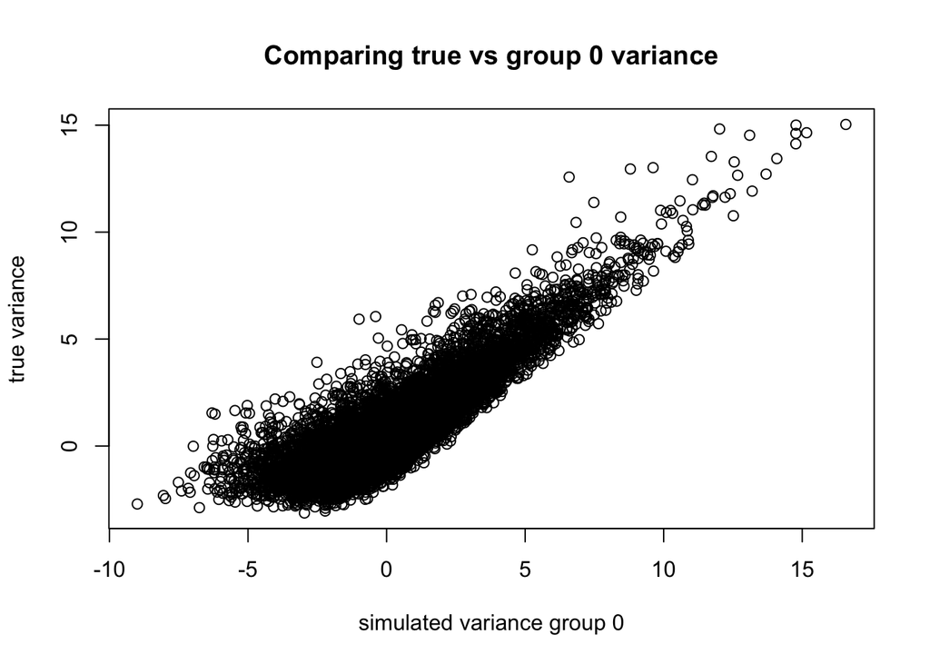

```r
row_var0 = apply(y[,grp == 0], 1, var)
row_var1 = apply(y[,grp == 1], 1, var)
row_var = apply(y, 1, var)

true_var = sd^2
plot(log(row_var0), log(true_var), xlab = 'simulated variance group 0', ylab = 'true variance', main = 'Comparing true vs group 0 variance')
```

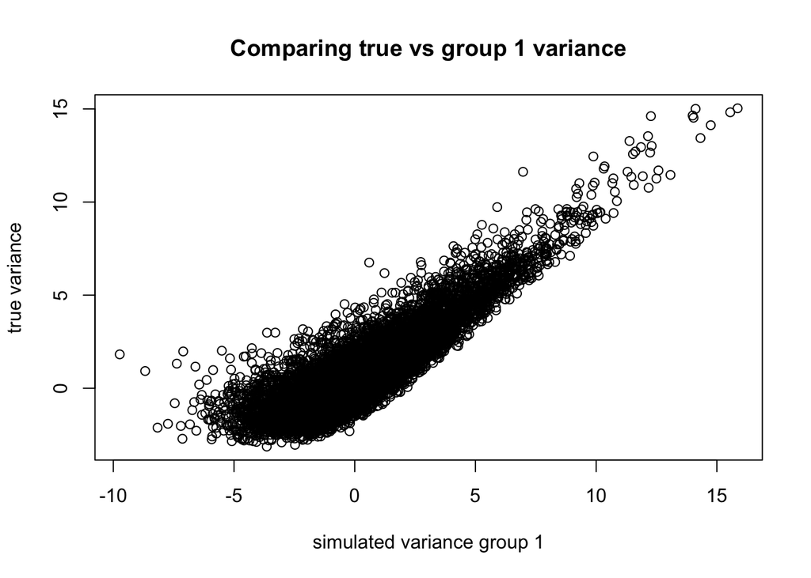

```r
plot(log(row_var1), log(true_var), xlab = 'simulated variance group 1', ylab = 'true variance', main = 'Comparing true vs group 1 variance')
```

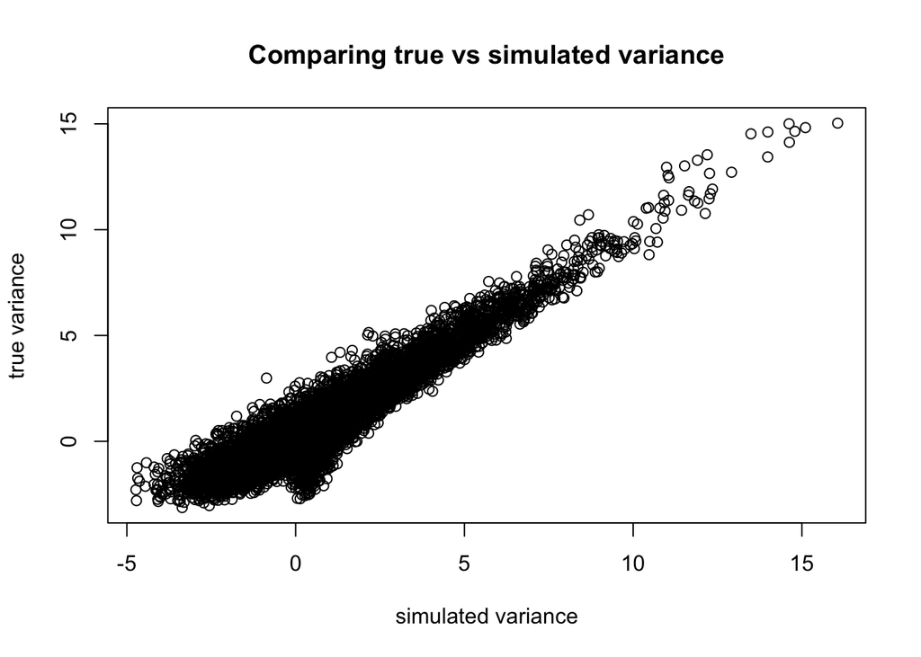

```r
plot(log(row_var), log(true_var), xlab = 'simulated variance', ylab = 'true variance', main ='Comparing true vs simulated variance')
```

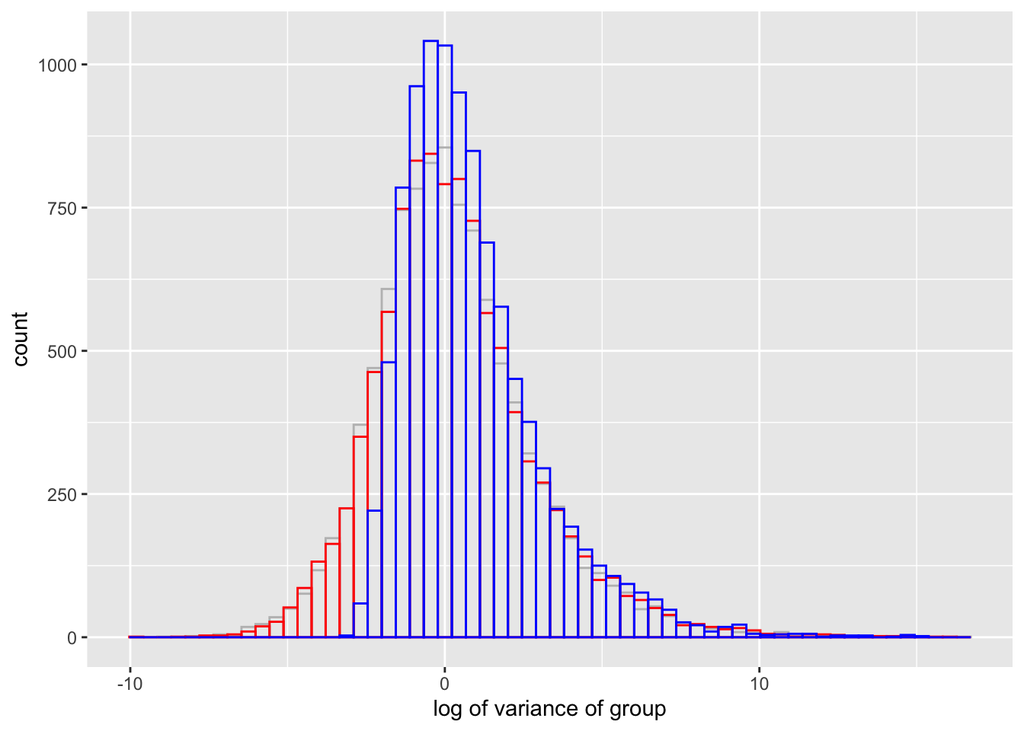

```r
gr1_df = as.data.frame(log(row_var0))
gr1_df$col = 'gr1'
gr2_df = as.data.frame(log(row_var1))
gr2_df$col = 'gr2'
true_df = as.data.frame(log(true_var))
true_df$col = 'true_var'

#all_var = rbind(gr1_df, gr2_df)
#all_var = rbind(all_var, true_df)

ggplot(gr1_df) +
  geom_histogram(aes(x=log(row_var0)), bins = 60, fill = 'transparent', color = 'grey') +
  geom_histogram(data = gr2_df, aes(x=log(row_var1)), bins = 60, fill = 'transparent', color = 'red') +
  geom_histogram(data = true_df, aes(x=log(true_var)), bins = 60, fill = 'transparent', color = 'blue', show.legend = T) +
  labs(x = 'log of variance of group') +
  scale_fill_manual(name="group",values=c("grey","red", 'blue'),labels=c("1","2", '3'))
```

```r
#+ legend('group 1', 'group 2')
```

Note that group 1 and group 2 (grey and red respectively) have a very similar distribution, however the true variance in blue, is similar yet with a fatter right tail.

# Q2: Differential expression

So we shifted the 1000 gene samples of group 1 by +2 or -2 out of 10 000. Hence we should see something similar to a normal distribution around 0, but slight elevation around -2 or +2.

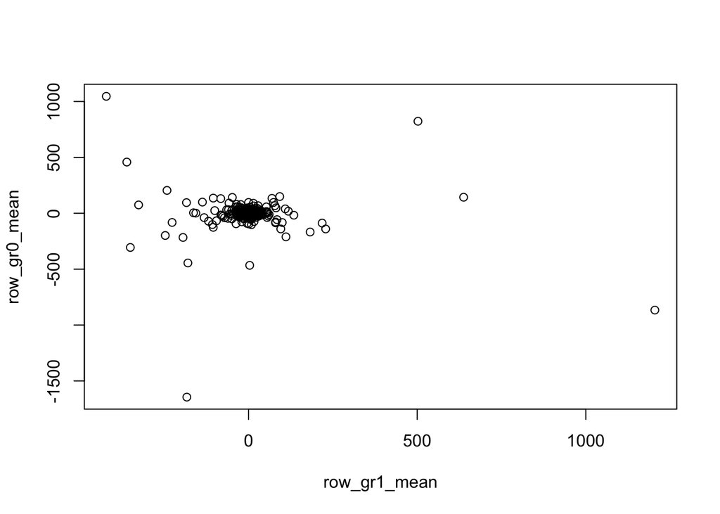

```r
y_df = as.data.frame(y)
row_gr0_mean = apply(y[, grp==0], 1, mean)
row_gr1_mean = apply(y[, grp==1], 1, mean)
row_gr0_mean_df = as.data.frame(row_gr0_mean)
row_gr1_mean_df = as.data.frame(row_gr1_mean)

plot(row_gr1_mean, row_gr0_mean)
```

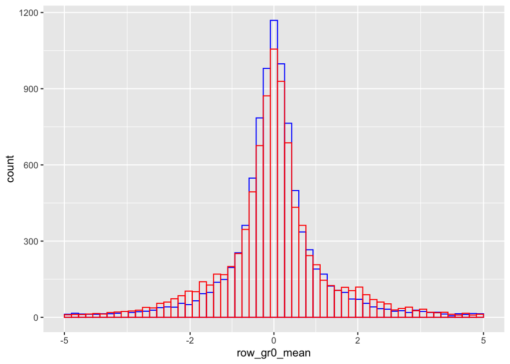

```r
ggplot(row_gr0_mean_df) +
  geom_histogram(aes(x=row_gr0_mean), bins = 60, fill = 'transparent', color = 'blue') +
  geom_histogram(data = row_gr1_mean_df, aes(x=row_gr1_mean), bins = 60, fill = 'transparent', color = 'red') +
  scale_x_continuous(limits=c(-5,5),breaks=c(-5, -2, 0, 2, 5))
```

The tails of the group 1 distribution are more fat (red), can even see a slight elevation around -2 and +2, so point proven. I zoomed in on the x-axis so these bulges would be visible on the plot.

```r
(design <- model.matrix(~grp))
```

```
  (Intercept) grp
1           1   0
2           1   0
3           1   0
4           1   1
5           1   1
6           1   1
attr(,"assign")
[1] 0 1
```

# Q3: meaning of columns in design matrix

The group is a categorical variable, it tells you which column in y (or row in the design matrix) is associated with this group. Intercept being one means we are fitting an intercept term in our model.

```r
fit <- lmFit(y,design)
fit <- eBayes(fit)

names(fit)
```

```
 [1] "coefficients"     "rank"             "assign"           "qr"
 [5] "df.residual"      "sigma"            "cov.coefficients" "stdev.unscaled"
 [9] "pivot"            "Amean"            "method"           "design"
[13] "df.prior"         "s2.prior"         "var.prior"        "proportion"
[17] "s2.post"          "t"                "df.total"         "p.value"
[21] "lods"             "F"                "F.p.value"
```

```r
summary(fit)
```

```
                 Length Class  Mode
coefficients     20000  -none- numeric
rank                 1  -none- numeric
assign               2  -none- numeric
qr                   5  qr     list
df.residual      10000  -none- numeric
sigma            10000  -none- numeric
cov.coefficients     4  -none- numeric
stdev.unscaled   20000  -none- numeric
pivot                2  -none- numeric
Amean            10000  -none- numeric
method               1  -none- character
design              12  -none- numeric
df.prior             1  -none- numeric
s2.prior             1  -none- numeric
var.prior            2  -none- numeric
proportion           1  -none- numeric
s2.post          10000  -none- numeric
t                20000  -none- numeric
df.total         10000  -none- numeric
p.value          20000  -none- numeric
lods             20000  -none- numeric
F                10000  -none- numeric
F.p.value        10000  -none- numeric
```

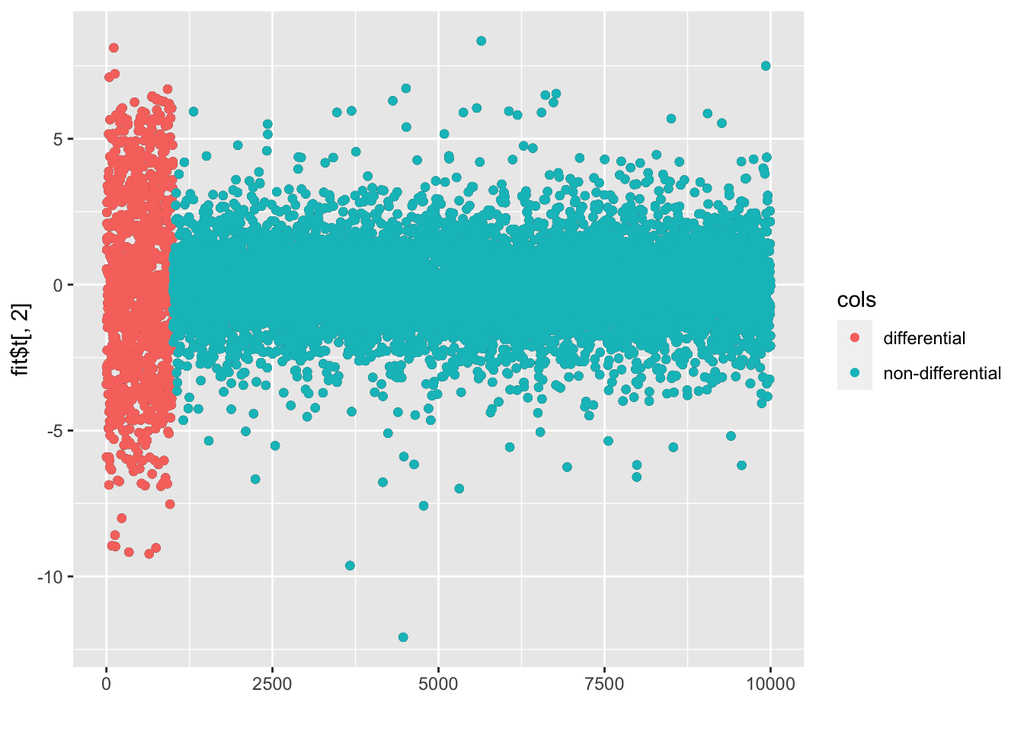

```r
cols <- rep("non-differential",nrow(y))
cols[indD] <- "differential"

qplot(y=fit$t[,2]) + geom_point(aes(colour=cols))
```

# Q4: t-test for column of y

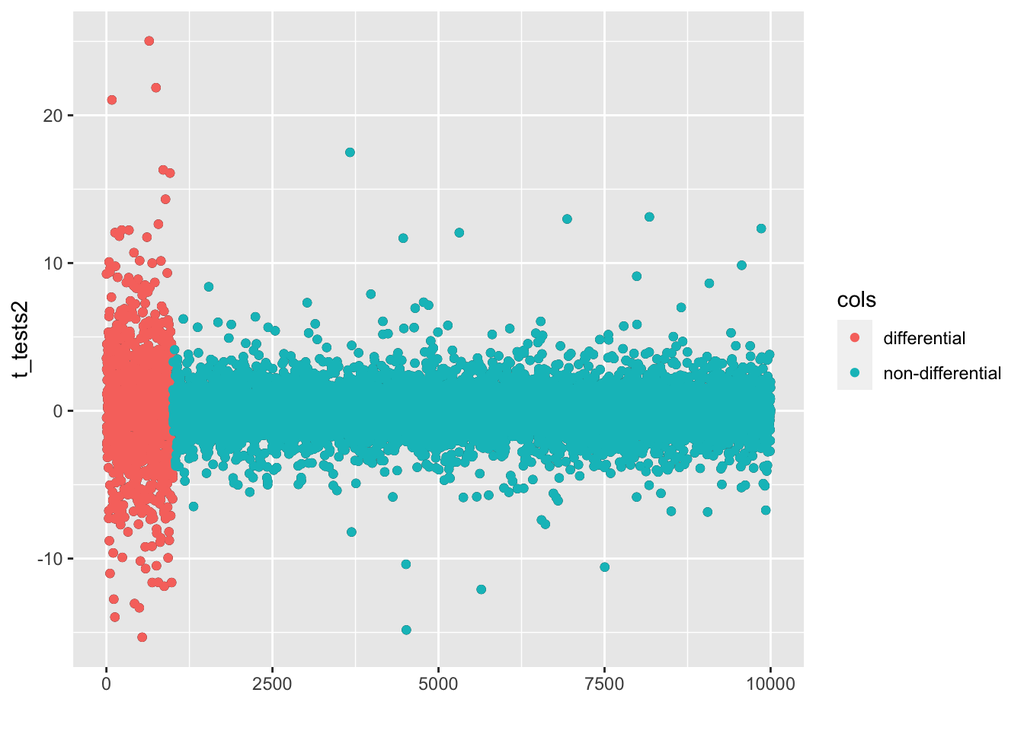

```r
ts_unpaired = function(y){
  return(t.test(y[grp == 0], y[grp == 1])$statistic)
}

t_tests2 = apply(y, 1, ts_unpaired)
qplot(y=t_tests2) + geom_point(aes(colour=cols))
```

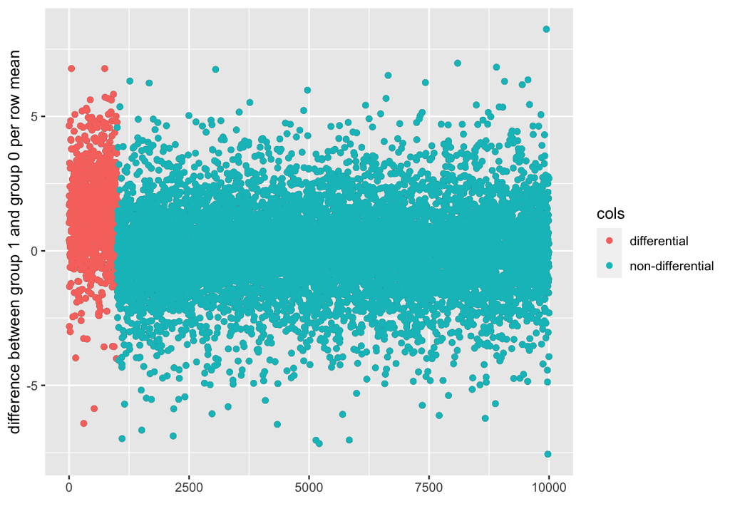

```r
diff_row_groups = log(abs(row_gr1_mean_df - row_gr0_mean_df))
div_row_groups = log(abs(row_gr1_mean_df / row_gr0_mean_df))

qplot(y=as.numeric(div_row_groups$row_gr1_mean)) + geom_point(aes(colour=cols)) + ylab('difference between group 1 and group 0 per row mean') #+ scale_y_continuous(limits=c(-10,10))
```

```r
#qplot(y=as.numeric(div_row_groups$row_gr1_mean)) + geom_point(aes(colour=cols)) + ylab('log(abs(ratio between group 1 and group 0 per row mean')
```

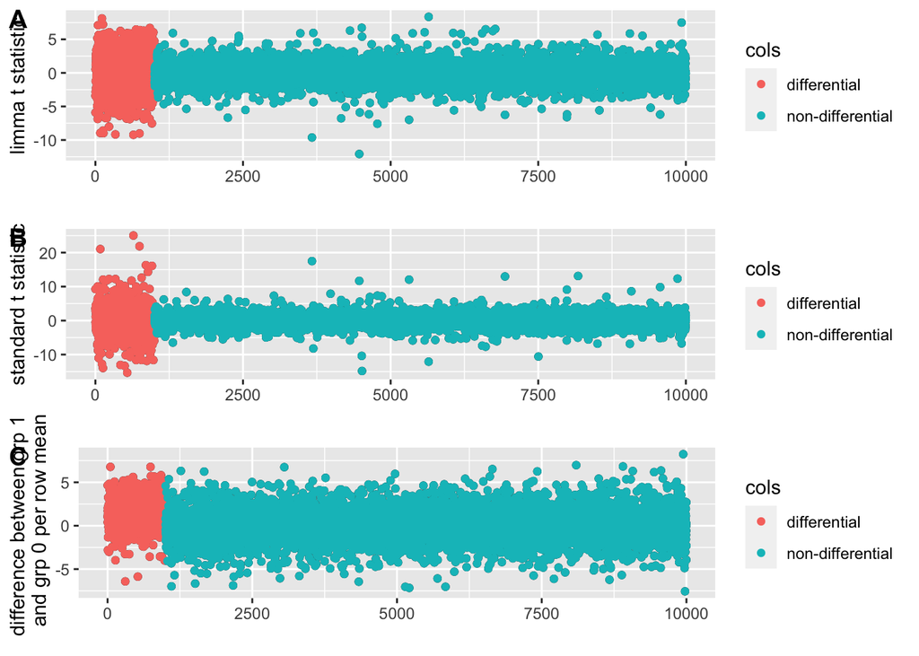

```r
library(ggpubr)
limma_plot = qplot(y=fit$t[,2]) + geom_point(aes(colour=cols)) + ylab('limma t statistic')
t_test_plot = qplot(y=t_tests2) + geom_point(aes(colour=cols)) + ylab('standard t statistic')
mean_diff_plot = qplot(y=as.numeric(div_row_groups$row_gr1_mean)) + geom_point(aes(colour=cols)) + ylab('difference between grp 1 \n and grp 0 per row mean') #+ scale_y_continuous(limits=c(-10,10))

figure <- ggarrange(limma_plot, t_test_plot, mean_diff_plot,
                    labels = c("A", "B", "C"),
                    ncol = 1, nrow = 3)
figure
```

# Q5: Metric to compare methods

ROC curve

```r
library(ROCR)

ts_unpaired_null = function(y){
  return(t.test(y[grp == 0], y[grp == 1])$p.value)
}

t_tests_null = apply(y, 1, ts_unpaired_null)
cols_test = rep(1, nrow(y))
p_val = 1e-1
cols_test[t_tests_null < p_val] = 1
cols_test[t_tests_null >= p_val] = 0
cols_binary = rep(1, nrow(y))
cols_binary[cols == 'differential'] = 1
cols_binary[cols == 'non-differential'] = 0

#qplot(y=t_tests_null) + geom_point(aes(colour=cols))
```

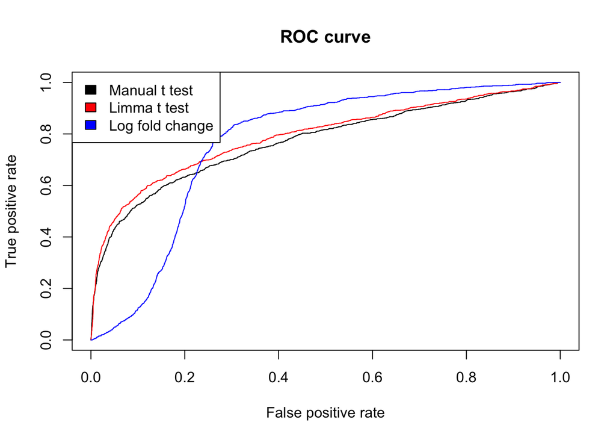

```r
#par(mfrow = c(1,3))
pred <- prediction(abs(t_tests2), cols=='differential')
perf <- performance(pred, measure = "tpr", x.measure = "fpr")
plot(perf, col='black', main = 'ROC curve')

pred <- prediction(abs(fit$t[,2]), cols== 'differential')
perf <- performance(pred, measure = "tpr", x.measure = "fpr")
plot(perf, col='red', add = TRUE)

pred <- prediction((diff_row_groups), cols== 'differential')
perf <- performance(pred, measure = "tpr", x.measure = "fpr")
plot(perf, col='blue', add = TRUE)

legend(x = "topleft", legend=c("Manual t test", "Limma t test", "Log fold change"), fill = c("black", "red","blue"))
```

```r
#pred <- prediction(fit$coef[,2], cols== 'differential')
#perf <- performance(pred, measure = "tpr", x.measure = "fpr")
#plot(perf, col='pink', add = TRUE)
```

From this I conclude that I would use the Limma t-test.

# Q6

```r
library("affy")
library("preprocessCore")
unzip("affy_estrogen.zip")
ddir <- "affy_estrogen"
dir(ddir)
```

```
[1] "high10-1.cel" "high10-2.cel" "high48-1.cel" "high48-2.cel" "low10-1.cel"
[6] "low10-2.cel"  "low48-1.cel"  "low48-2.cel"  "targets.txt"
```

```r
# preprocess affymetrix data
targets <- readTargets("targets.txt", path=ddir)
targets$time.h <- factor(targets$time.h)
targets
```

```
      filename estrogen time.h
1  low10-1.cel   absent     10
2  low10-2.cel   absent     10
3 high10-1.cel  present     10
4 high10-2.cel  present     10
5  low48-1.cel   absent     48
6  low48-2.cel   absent     48
7 high48-1.cel  present     48
8 high48-2.cel  present     48
```

```r
abatch <- ReadAffy(filenames=targets$filename,
                   celfile.path=ddir)
eset <- rma(abatch)  # bg correct, normalize, summarize
```

```
Background correcting
Normalizing
Calculating Expression
```

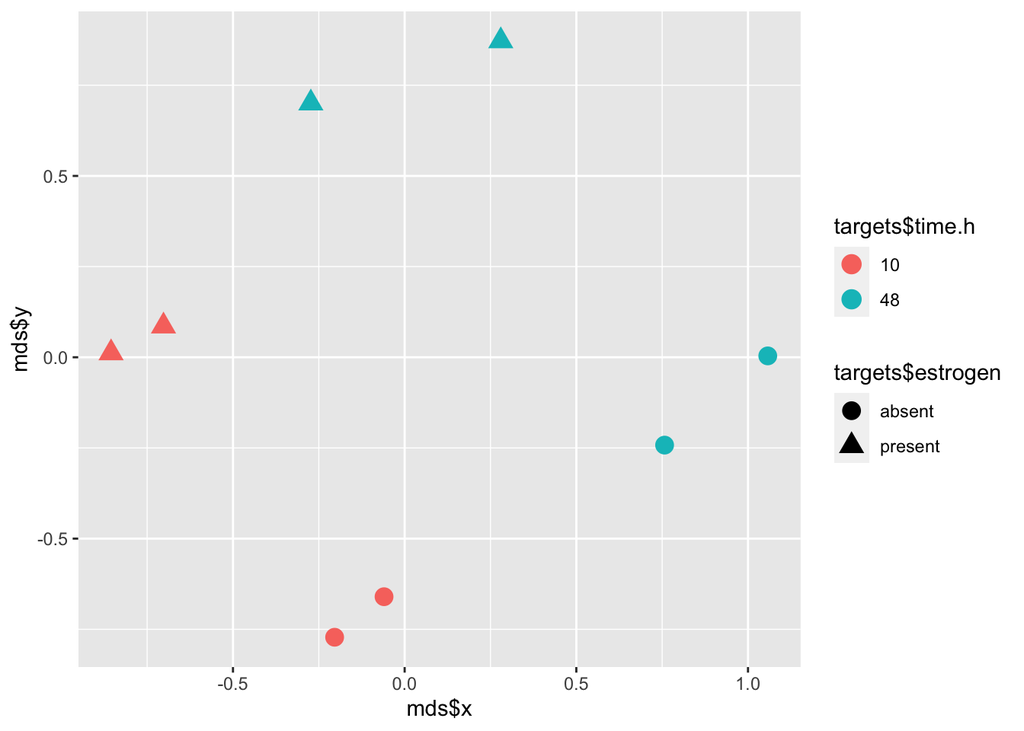

```r
mds <- plotMDS( exprs(eset), plot = FALSE)  # MDS plot
qplot(x=mds$x, mds$y) +
  geom_point(aes(shape=targets$estrogen,
                 colour=targets$time.h), size=4)
```

```r
# do the limma modeling
f <- paste(targets$estrogen,targets$time.h,sep="")
f <- factor(f)

# create design matrix
design <- model.matrix(~0+f)
colnames(design) <- levels(f)
design
```

```
  absent10 absent48 present10 present48
1        1        0         0         0
2        1        0         0         0
3        0        0         1         0
4        0        0         1         0
5        0        1         0         0
6        0        1         0         0
7        0        0         0         1
8        0        0         0         1
attr(,"assign")
[1] 1 1 1 1
attr(,"contrasts")
attr(,"contrasts")$f
[1] "contr.treatment"
```

```r
fit <- lmFit(eset, design)

cont.matrix <- makeContrasts(E10="present10-absent10",
                             E48="present48-absent48",
                             Time="absent48-absent10",levels=design)
cont.matrix
```

```
           Contrasts
Levels      E10 E48 Time
  absent10   -1   0   -1
  absent48    0  -1    1
  present10   1   0    0
  present48   0   1    0
```

```r
fit2  <- contrasts.fit(fit, cont.matrix)
fit2  <- eBayes(fit2)
class(fit2)
```

```
[1] "MArrayLM"
attr(,"package")
[1] "limma"
```

```r
names(fit2)
```

```
 [1] "coefficients"     "rank"             "assign"           "qr"
 [5] "df.residual"      "sigma"            "cov.coefficients" "stdev.unscaled"
 [9] "pivot"            "Amean"            "method"           "design"
[13] "contrasts"        "df.prior"         "s2.prior"         "var.prior"
[17] "proportion"       "s2.post"          "t"                "df.total"
[21] "p.value"          "lods"             "F"                "F.p.value"
```

```r
topTable(fit2, coef=1, n=5)
```

```
            logFC   AveExpr        t      P.Value    adj.P.Val        B
39642_at 2.939428  7.876515 23.71715 4.741579e-09 3.128295e-05 9.966810
910_at   3.113733  9.660238 23.59225 4.955715e-09 3.128295e-05 9.942522
31798_at 2.800195 12.115778 16.38509 1.025747e-07 3.511070e-04 7.977290
41400_at 2.381040 10.041553 16.22463 1.112418e-07 3.511070e-04 7.916921
40117_at 2.555282  9.676557 15.68070 1.472942e-07 3.576234e-04 7.705093
```

```r
topTable(fit2, coef=2, n=5)
```

```
            logFC   AveExpr        t      P.Value    adj.P.Val         B
910_at   3.855061  9.660238 29.20918 8.266125e-10 1.043598e-05 11.606193
31798_at 3.597334 12.115778 21.04947 1.284430e-08 7.631722e-05  9.890557
1854_at  3.340896  8.532099 20.19564 1.813478e-08 7.631722e-05  9.641399
38116_at 3.758891  9.513109 16.85669 8.116230e-08 2.511100e-04  8.480197
38065_at 2.993641  9.097183 16.20914 1.121213e-07 2.511100e-04  8.214175
```

```r
topTable(fit2, coef=3, n=5)
```

```
                    logFC   AveExpr         t      P.Value    adj.P.Val
AFFX-CreX-5_at  -6.826151  9.921026 -32.81011 3.108614e-10 2.703546e-06
AFFX-CreX-3_at  -6.526324 10.406343 -31.58459 4.282844e-10 2.703546e-06
AFFX-BioDn-5_at -3.734781  8.348424 -19.15515 2.815350e-08 1.184793e-04
AFFX-BioB-M_at  -3.408360  8.270105 -18.28381 4.143024e-08 1.307642e-04
AFFX-BioDn-3_at -2.485797 11.401080 -15.52522 1.598695e-07 4.036706e-04
                        B
AFFX-CreX-5_at  10.655112
AFFX-CreX-3_at  10.547986
AFFX-BioDn-5_at  8.575319
AFFX-BioB-M_at   8.336458
AFFX-BioDn-3_at  7.427475
```

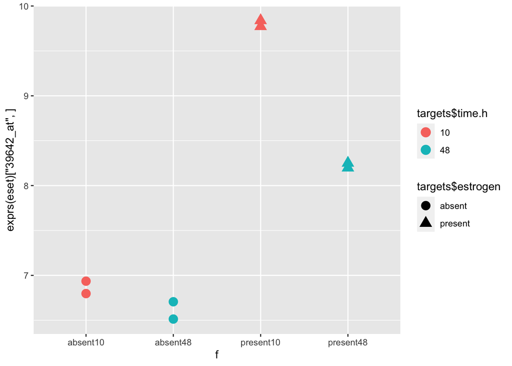

```r
qplot(x=f, y=exprs(eset)["39642_at",],) +
  geom_point(aes(shape=targets$estrogen,
                 colour=targets$time.h), size=4)
```

After design matrix it may make sense to filter out control probesets or remove lowly expressed genes.

ANSWER

```r
aff_dat = exprs(eset)
#910_at present48-absent48
at_910 = aff_dat['910_at', ]
logFC_2 = (at_910['high48-2.cel']+at_910['high48-1.cel'])/2 - (at_910['low48-2.cel']+at_910['low48-1.cel'])/2
logFC_2
```

```
high48-2.cel
    3.855061
```

```r
logFC_1 = (at_910['high10-2.cel']+at_910['high10-1.cel'])/2 - (at_910['low10-2.cel']+at_910['low10-1.cel'])/2
logFC_1
```

```
high10-2.cel
    3.113733
```

```r
logFC_3 = (at_910['low48-2.cel']+at_910['low48-1.cel'])/2 - (at_910['low10-2.cel']+at_910['low10-1.cel'])/2
logFC_3
```

```
low48-2.cel
   -1.33371
```

```r
ave_expr = mean(at_910)
```